# Pedagogy model

# Full model predictions

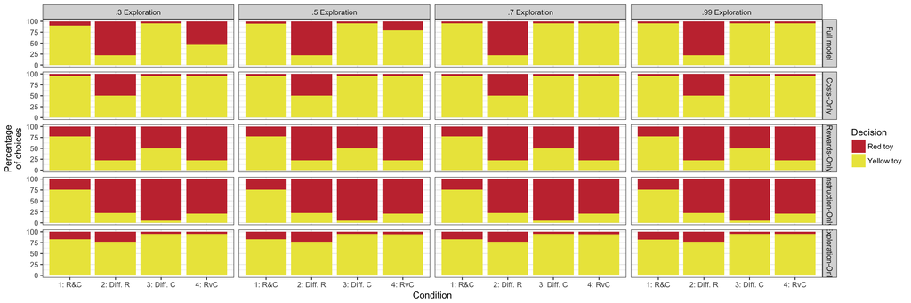

# Model fits. Using 50% exploration chance.

In each plot, entry i,j (row i, column j) shows the likelihood of model i generating the empirical data divided by the likelihood of model j generating the empirical data. Thus, values above 1 (green color-coded) indicate that the row model has a higher likelihood of generating the empirical data than the column model. Conversely, values below 1 (red color-coded) indicate that the row model has a lower likelihood of generating the empirical data than the column model. Values equal to 1 (blue color-coded) indicate both models are equally likely to have generated the data. For each section, alpha indicates the probability that participants get distracted and respond at chance.

As the plots above show, the full model outperforms all other alternative models for a wide range of noise parameters.

## Alpha = 0.01

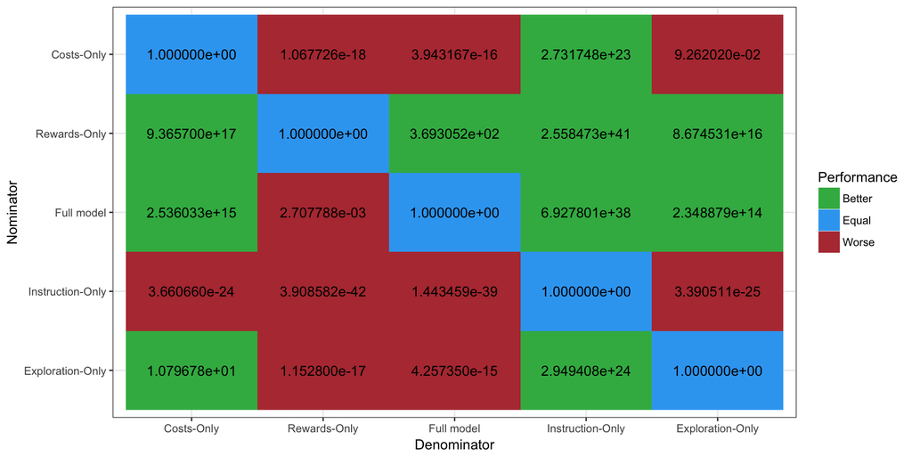

## Alpha = 0.05

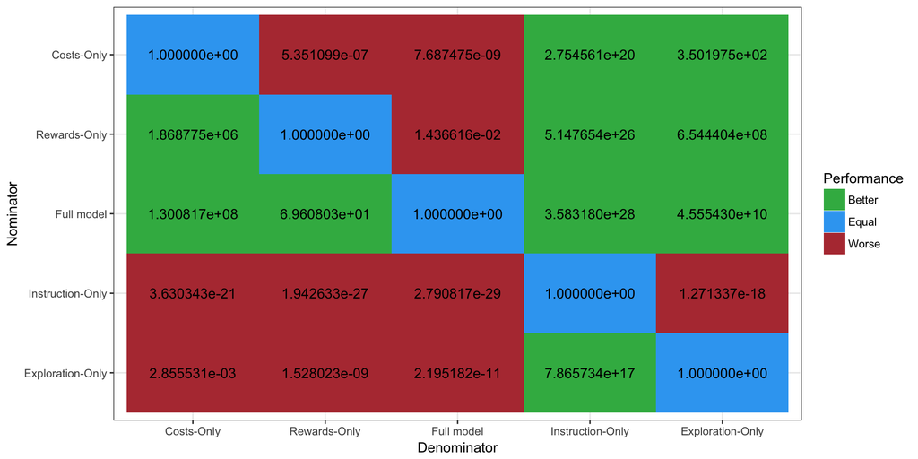

## Alpha = 0.1

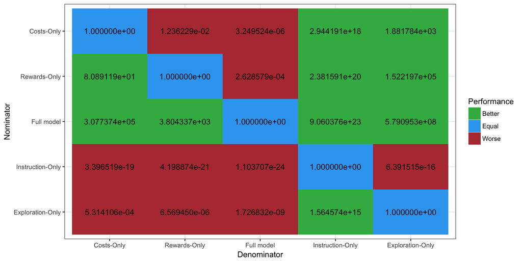

## Alpha = 0.2

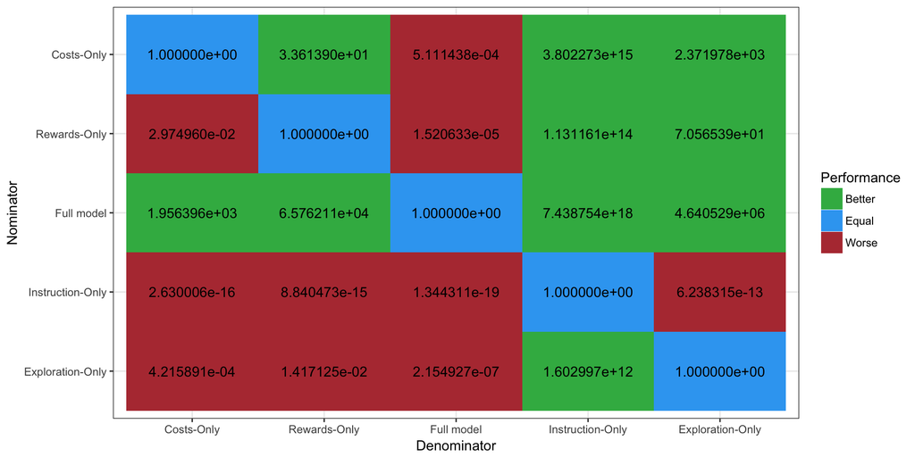

## Alpha = 0.3

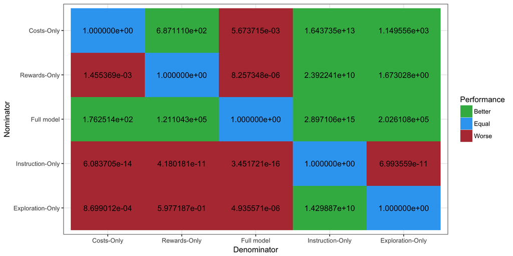

## Alpha = 0.4

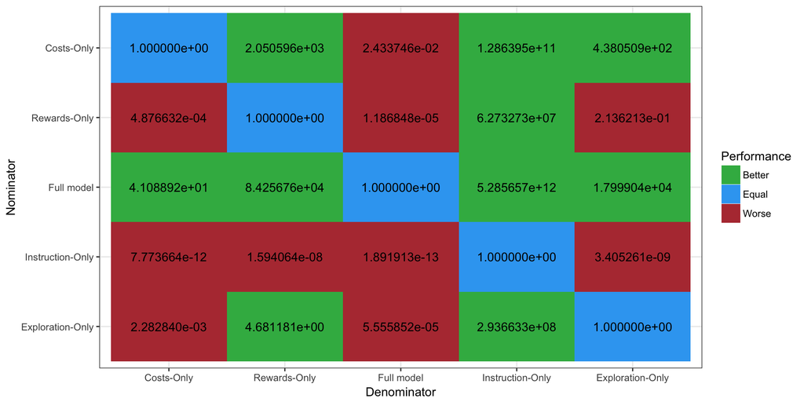

## Alpha = 0.5

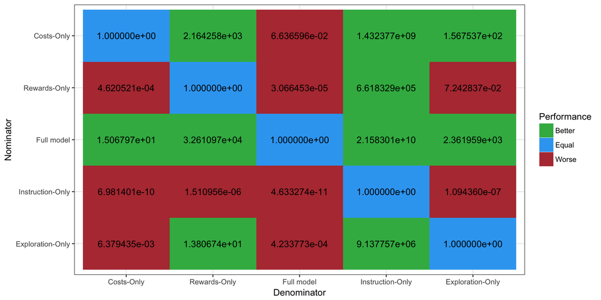

# Likelihood per condition

Likelihood of each model generating the data of each individual condition when exploration uncertainty = 0.5 and noise = 0.1

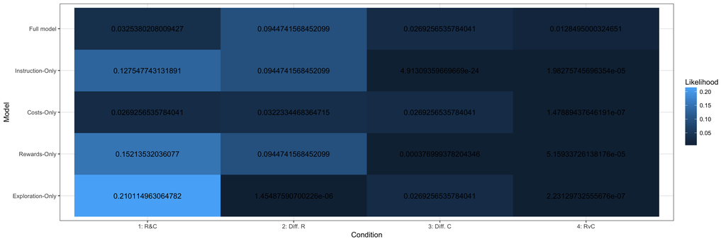

# Noise summary

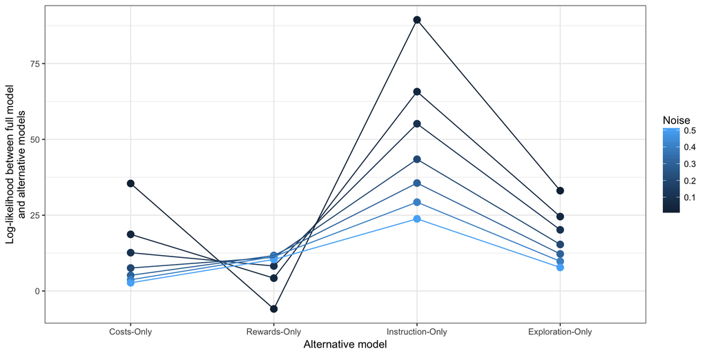